# Laboratorio 1 - Análisis exploratorio, PCA y Apriori

#### 4. Aislar variables numéricas y categóricas

#correlacion

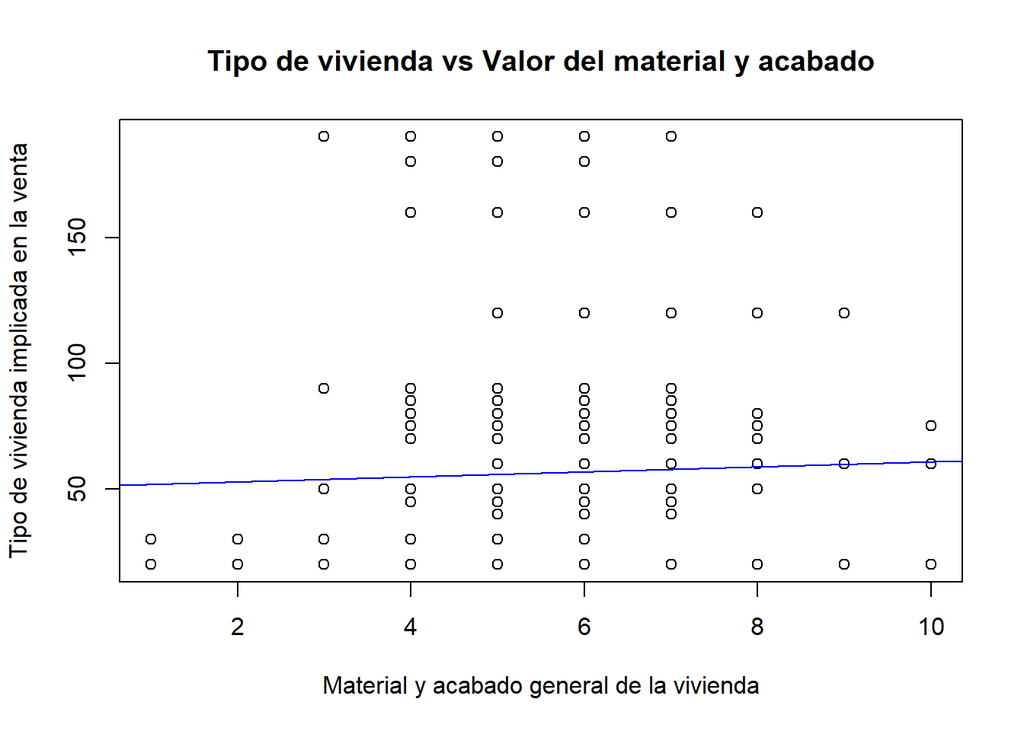

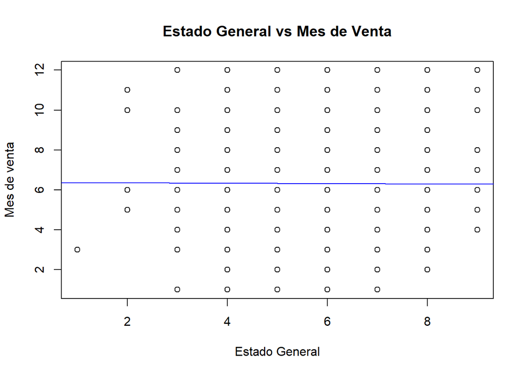

En las graficas podemos observar que no existe correlacion entre esas variables categoricas, representadas numericamente. Asi que podemos concluir que no existe relacion entre las variables que identifican el tipo de vivienda implicada en la venta y la que Valora el material y el acabado general de la vivienda como podemos observar en la primer grafica. En la segunda vemos que no hay relacion entre las variables que valoran el estado general de la vivienda y el mes de la venta.

#### 5. Variables Categoricas

## Tablas de frecuencia

#MSZoning

```
##
## C (all)      FV      RH      RL      RM
##      10      65      16    1151     218
```

#Street

```
##
## Grvl Pave
##    6 1454
```

#Alley

```
##
## Grvl Pave
##   50   41
```

#LotShape

```
##
## IR1 IR2 IR3 Reg
## 484  41  10 925
```

#LandContour

```
##
##  Bnk  HLS  Low  Lvl
##   63   50   36 1311
```

#Utilities

```
##
## AllPub NoSeWa
##   1459      1
```

#LotConfig

```
##
##  Corner CulDSac     FR2     FR3  Inside
##     263      94      47       4    1052
```

#LandSlope

```
##
##  Gtl  Mod  Sev
## 1382   65   13
```

#Neighborhood

```
##
## Blmngtn Blueste  BrDale BrkSide ClearCr CollgCr Crawfor Edwards Gilbert  IDOTRR
##      17       2      16      58      28     150      51     100      79      37
## MeadowV Mitchel   NAmes NoRidge NPkVill NridgHt  NWAmes OldTown  Sawyer SawyerW
##      17      49     225      41       9      77      73     113      74      59
## Somerst StoneBr   SWISU  Timber Veenker
##      86      25      25      38      11
```

#Condition1

```
##
## Artery  Feedr   Norm   PosA   PosN   RRAe   RRAn   RRNe   RRNn
##     48     81   1260      8     19     11     26      2      5
```

#Condition2

```
##
## Artery  Feedr   Norm   PosA   PosN   RRAe   RRAn   RRNn
##      2      6   1445      1      2      1      1      2
```

#BldgType

```
##
##   1Fam 2fmCon Duplex  Twnhs TwnhsE
##   1220     31     52     43    114
```

#HouseStyle

```
##
## 1.5Fin 1.5Unf 1Story 2.5Fin 2.5Unf 2Story SFoyer   SLvl
##    154     14    726      8     11    445     37     65
```

#RoofStyle

```
##
##    Flat   Gable Gambrel     Hip Mansard    Shed
##      13    1141      11     286       7       2
```

#RoofMatl

```
##
## ClyTile CompShg Membran   Metal    Roll Tar&Grv WdShake WdShngl
##       1    1434       1       1       1      11       5       6
```

#Exterior1st

```
##
## AsbShng AsphShn BrkComm BrkFace  CBlock CemntBd HdBoard ImStucc MetalSd Plywood
##      20       1       2      50       1      61     222       1     220     108
##   Stone  Stucco VinylSd Wd Sdng WdShing
##       2      25     515     206      26
```

#Exterior2nd

```
##
## AsbShng AsphShn Brk Cmn BrkFace  CBlock CmentBd HdBoard ImStucc MetalSd   Other
##      20       3       7      25       1      60     207      10     214       1
## Plywood   Stone  Stucco VinylSd Wd Sdng Wd Shng
##     142       5      26     504     197      38
```

#MasVnrType

```
##
##  BrkCmn BrkFace    None   Stone
##      15     445     864     128
```

#ExterQual

```
##
##  Ex  Fa  Gd  TA
##  52  14 488 906
```

#ExterCond

```
##
##   Ex   Fa   Gd   Po   TA
##    3   28  146    1 1282
```

#Foundation

```
##
## BrkTil CBlock  PConc   Slab  Stone   Wood
##    146    634    647     24      6      3
```

#BsmtQual

```
##
##  Ex  Fa  Gd  TA
## 121  35 618 649
```

#BsmtCond

```
##
##   Fa   Gd   Po   TA
##   45   65    2 1311
```

#BsmtExposure

```
##
##  Av  Gd  Mn  No
## 221 134 114 953
```

#BsmtFinType1

```
##
## ALQ BLQ GLQ LwQ Rec Unf
## 220 148 418  74 133 430
```

#BsmtFinType2

```
##
##  ALQ  BLQ  GLQ  LwQ  Rec  Unf
##   19   33   14   46   54 1256
```

#Heating

```
##
## Floor  GasA  GasW  Grav  OthW  Wall
##     1  1428    18     7     2     4
```

#HeatingQC

```
##
##  Ex  Fa  Gd  Po  TA
## 741  49 241   1 428
```

#CentralAir

```
##
##    N    Y
##   95 1365
```

#Electrical

```
##
## FuseA FuseF FuseP   Mix SBrkr
##    94    27     3     1  1334
```

#KitchenQual

```
##
##  Ex  Fa  Gd  TA
## 100  39 586 735
```

#Functional

```
##
## Maj1 Maj2 Min1 Min2  Mod  Sev  Typ
##   14    5   31   34   15    1 1360
```

#FireplaceQu

```
##
##  Ex  Fa  Gd  Po  TA
##  24  33 380  20 313
```

#GarageType

```
##
##  2Types  Attchd Basment BuiltIn CarPort  Detchd
##       6     870      19      88       9     387
```

#GarageFinish

```
##
## Fin RFn Unf
## 352 422 605
```

#GarageQual

```
##
##   Ex   Fa   Gd   Po   TA
##    3   48   14    3 1311
```

#GarageCond

```
##
##   Ex   Fa   Gd   Po   TA
##    2   35    9    7 1326
```

#PavedDrive

```
##
##    N    P    Y
##   90   30 1340
```

#PoolQC

```
##
## Ex Fa Gd
##  2  2  3
```

#Fence

```
##
## GdPrv  GdWo MnPrv  MnWw
##    59    54   157    11
```

#MiscFeature

```
##
## Gar2 Othr Shed TenC
##    2    2   49    1
```

#SaleType

```
##
##   COD   Con ConLD ConLI ConLw   CWD   New   Oth    WD
##    43     2     9     5     5     4   122     3  1267
```

#SaleCondition

```
##
## Abnorml AdjLand  Alloca  Family  Normal Partial
##     101       4      12      20    1198     125
```

# Graficos

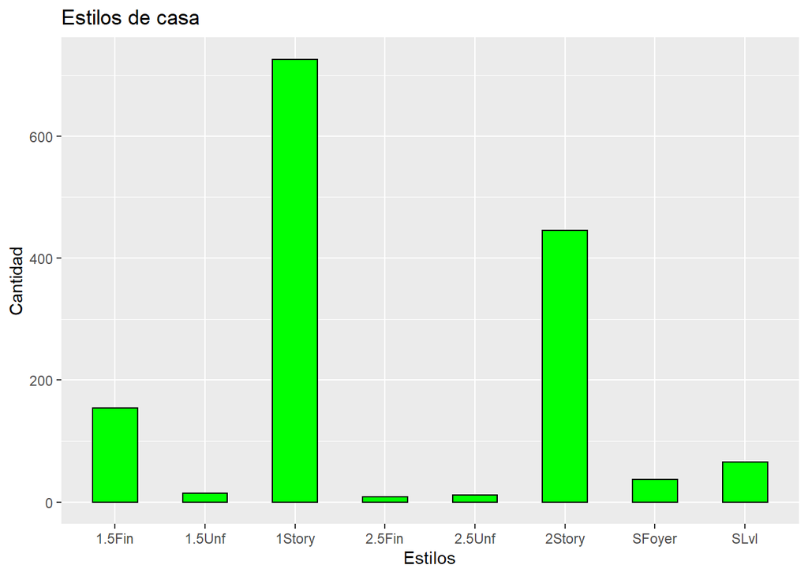

Las casas que predominan el mercado son las de un nivel.

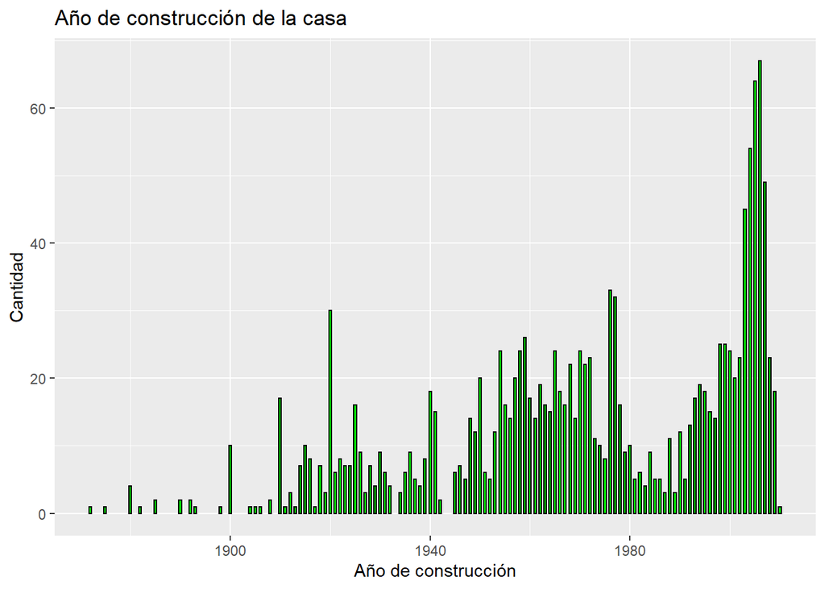

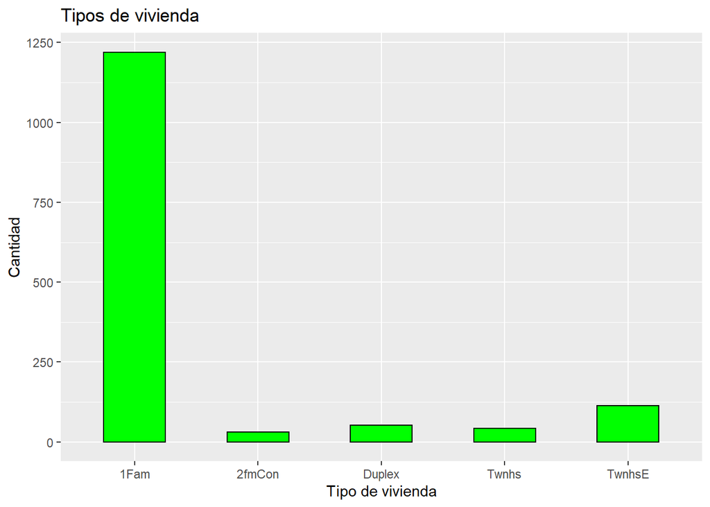

Los tipos de casas más populares, son aquellos que fueron diseñados para una sola familia.

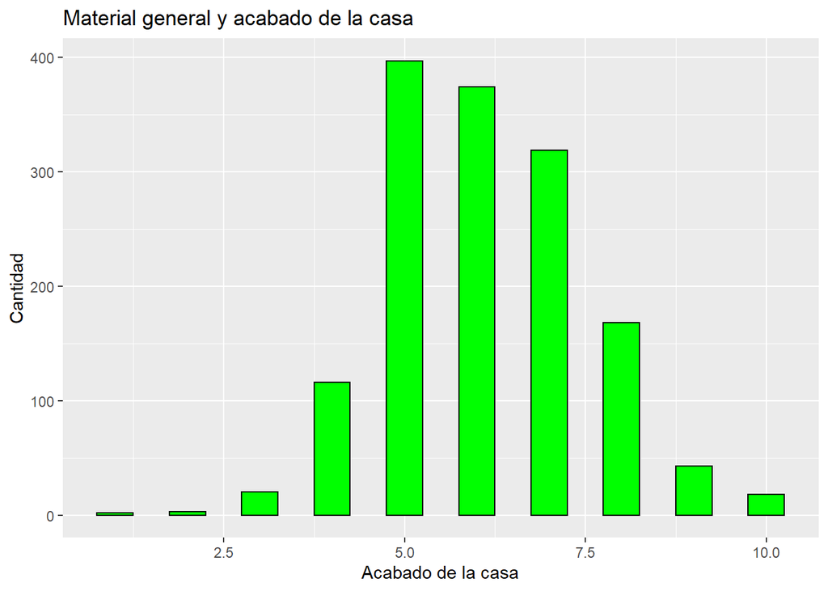

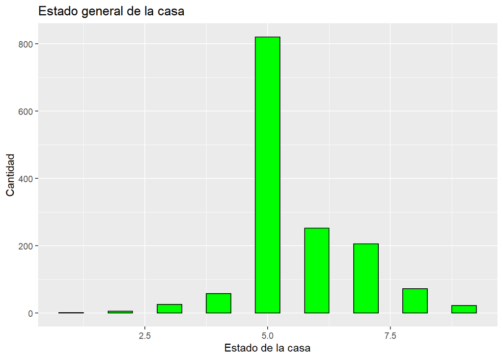

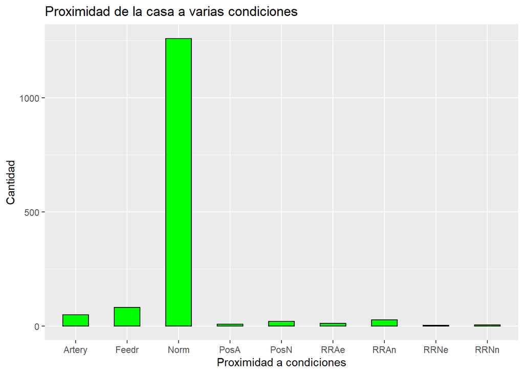

La proximidad más popular o que más se da es la normal.

#### 6. Analisis de Componentes Principales

```
## [1] 0.818443
```

```
## [1] 0.5
```

```
## [1] 240.12
```

```
## $KMO
## [1] 0.5
##
## $MSA
##             MSA
## LotFrontage 0.5
## LotArea     0.5
##
## $Bartlett
## [1] 240.12
##
## $Communalities
##             Initial Communalities Final Extraction
## LotFrontage               0.18156          0.42514
## LotArea                   0.18156          0.42514
##
## $Factor.Loadings
##                [,1]
## LotFrontage 0.65203
## LotArea     0.65203
##
## $RMS
## [1] 0.00095523
```

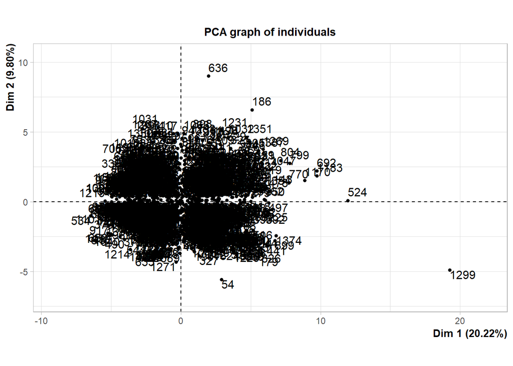

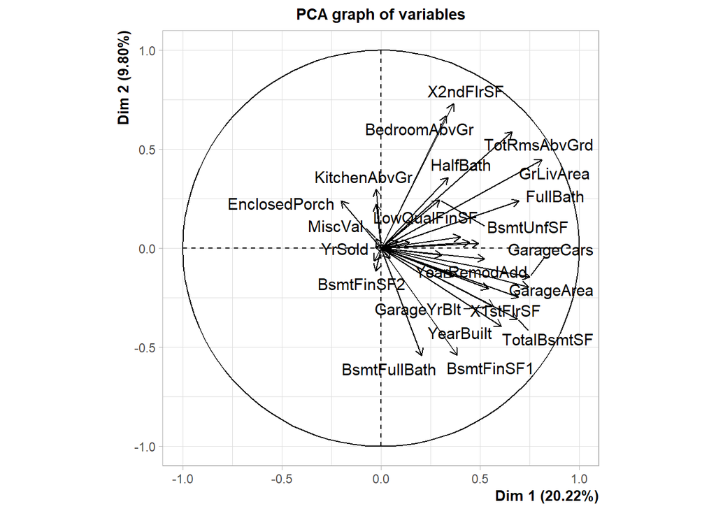

```
##
## Call:
## PCA(X = train_cuanti)
##
##
## Eigenvalues
##                        Dim.1   Dim.2   Dim.3   Dim.4   Dim.5   Dim.6   Dim.7
## Variance               6.469   3.134   2.439   1.885   1.299   1.129   1.111
## % of var.             20.217   9.795   7.621   5.891   4.058   3.528   3.473
## Cumulative % of var.  20.217  30.012  37.633  43.524  47.582  51.110  54.583
##                        Dim.8   Dim.9  Dim.10  Dim.11  Dim.12  Dim.13  Dim.14
## Variance               1.094   1.049   1.030   1.011   0.953   0.921   0.905
## % of var.              3.420   3.279   3.219   3.161   2.979   2.878   2.830
## Cumulative % of var.  58.003  61.283  64.501  67.662  70.641  73.519  76.349
##                       Dim.15  Dim.16  Dim.17  Dim.18  Dim.19  Dim.20  Dim.21
## Variance               0.877   0.839   0.762   0.724   0.660   0.625   0.586
## % of var.              2.742   2.621   2.382   2.261   2.061   1.955   1.831
## Cumulative % of var.  79.090  81.711  84.093  86.354  88.415  90.370  92.201
##                       Dim.22  Dim.23  Dim.24  Dim.25  Dim.26  Dim.27  Dim.28
## Variance               0.543   0.427   0.387   0.305   0.248   0.201   0.158
## % of var.              1.696   1.335   1.209   0.954   0.774   0.627   0.494
## Cumulative % of var.  93.897  95.232  96.441  97.396  98.169  98.796  99.290
##                       Dim.29  Dim.30  Dim.31  Dim.32
## Variance               0.132   0.096   0.000   0.000
## % of var.              0.412   0.299   0.000   0.000
## Cumulative % of var.  99.701 100.000 100.000 100.000
##
## Individuals (the 10 first)
##                   Dist    Dim.1    ctr   cos2    Dim.2    ctr   cos2    Dim.3
## 1             |  3.637 |  1.314  0.018  0.130 |  0.231  0.001  0.004 | -1.459
## 2             |  5.064 |  0.189  0.000  0.001 | -1.022  0.023  0.041 |  0.794
## 3             |  3.208 |  1.443  0.022  0.202 |  0.070  0.000  0.000 | -1.275
## 4             |  5.781 | -0.586  0.004  0.010 |  1.148  0.029  0.039 |  1.039
## 5             |  4.920 |  4.133  0.181  0.705 |  0.912  0.018  0.034 | -0.466
## 6             | 11.668 | -0.583  0.004  0.002 | -2.078  0.094  0.032 | -0.964
## 7             |  4.326 |  2.808  0.083  0.421 | -2.448  0.131  0.320 |  0.538
## 8             |  5.801 |  1.927  0.039  0.110 |  1.111  0.027  0.037 |  1.601
## 9             |  7.062 | -1.112  0.013  0.025 |  3.070  0.206  0.189 |  1.743
## 10            |  6.583 | -2.916  0.090  0.196 | -0.553  0.007  0.007 |  2.554
##                  ctr   cos2
```

[output cut: 19 more lines]

```
## BsmtFinSF2    | -0.025  0.010  0.001 | -0.114  0.418  0.013 |  0.299  3.657
## BsmtUnfSF     |  0.296  1.356  0.088 |  0.244  1.898  0.060 | -0.298  3.645
## TotalBsmtSF   |  0.690  7.350  0.475 | -0.357  4.058  0.127 |  0.271  3.022
## X1stFlrSF     |  0.695  7.467  0.483 | -0.247  1.954  0.061 |  0.381  5.937
##                 cos2
## LotFrontage    0.131 |
## LotArea        0.187 |
## YearBuilt      0.253 |
## YearRemodAdd   0.213 |
## MasVnrArea     0.000 |
## BsmtFinSF1     0.197 |
## BsmtFinSF2     0.089 |
## BsmtUnfSF      0.089 |
## TotalBsmtSF    0.074 |
## X1stFlrSF      0.145 |
```

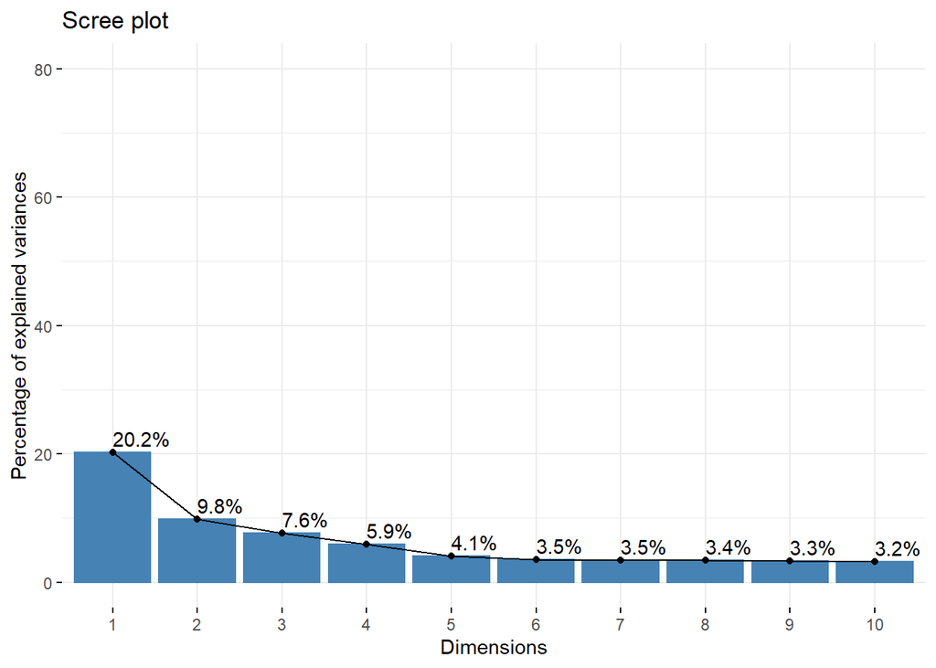

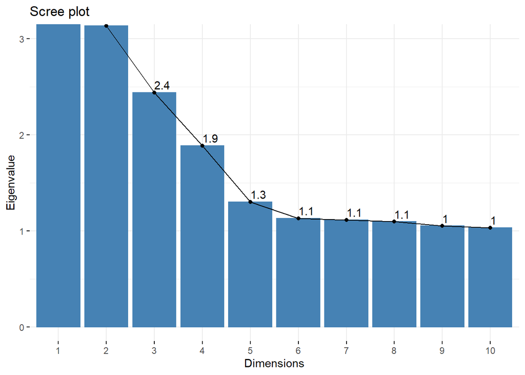

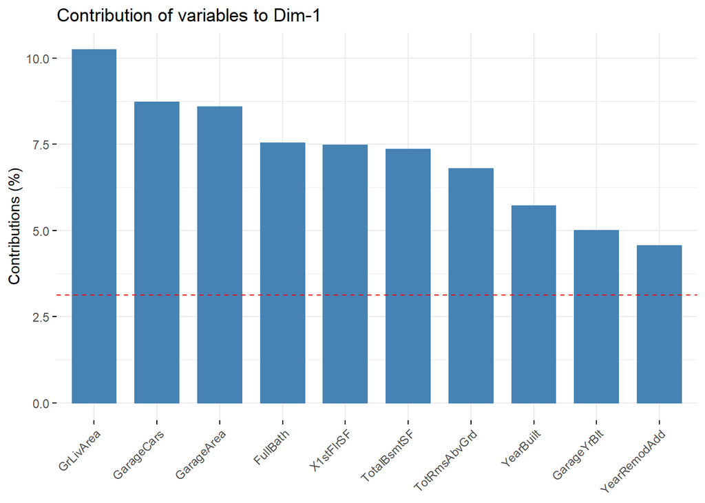

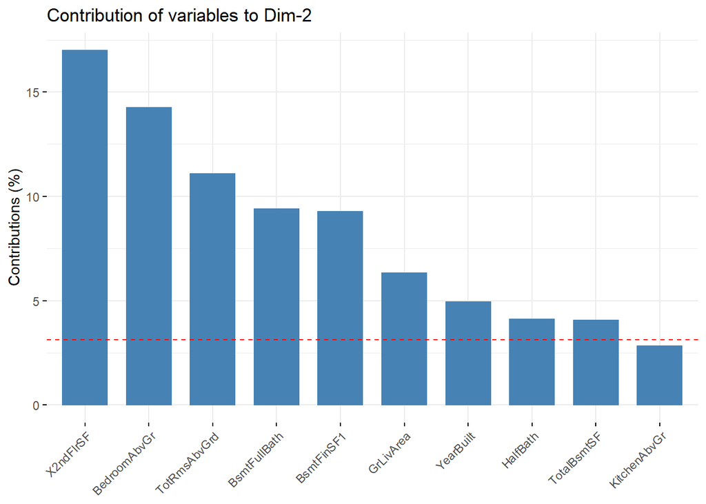

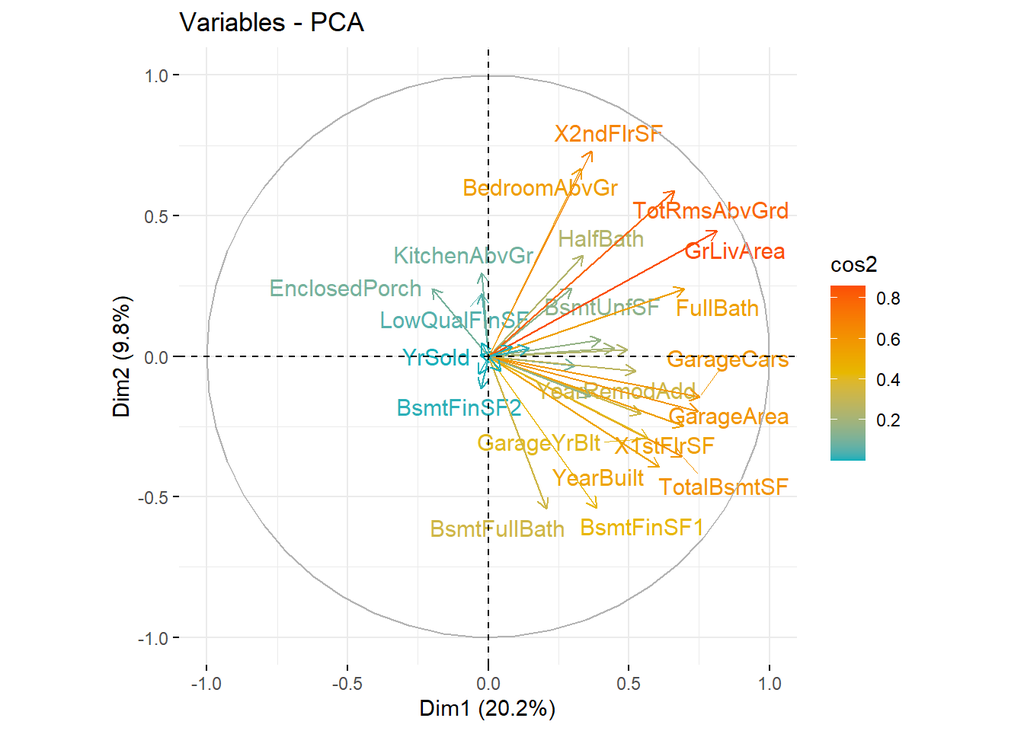

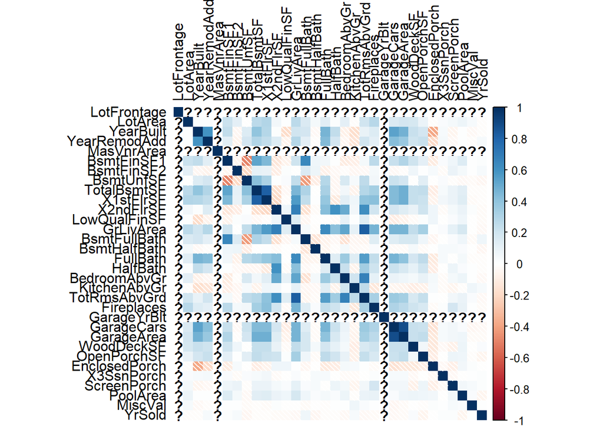

### 7. Regla de asociacion

```
## Apriori
##
## Parameter specification:
##  confidence minval smax arem  aval originalSupport maxtime support minlen
##         0.7    0.1    1 none FALSE            TRUE       5     0.2      1
##  maxlen target  ext
##      10  rules TRUE
##
## Algorithmic control:
##  filter tree heap memopt load sort verbose
##     0.1 TRUE TRUE  FALSE TRUE    2    TRUE
##
## Absolute minimum support count: 292
##
## set item appearances ...[0 item(s)] done [0.00s].
## set transactions ...[339 item(s), 1460 transaction(s)] done [0.04s].
## sorting and recoding items ... [134 item(s)] done [0.01s].
## creating transaction tree ... done [0.00s].
## checking subsets of size 1 2 3 4
```

```
##  done [6.29s].
## writing ... [2950062 rule(s)] done [1.83s].
## creating S4 object  ... done [3.76s].
```